# 17 Probability distributions

Author

Affiliation

Vladimir Buskin

Catholic University of Eichstätt-Ingolstadt

## 17.1 Suggested reading

> Baguley (2012): Chapter 2

> Agresti and Kateri (2022): Chapter 2

> Heumann, Schomaker, and Shalabh (2022): Chapter 8

## 17.2 Continuous distributions

### 17.2.1 The normal distribution

A great number of numerical variables in the world follow the well-known **normal** (or Gaussian) **distribution**, which includes test scores, weight and height, among many others. The plot below illustrates its characteristic bell-shape: Most observations are in the middle, with considerably fewer near the fringes. For example, most people are rather “average” in height; there are only few people that are extremely short or extremely tall.

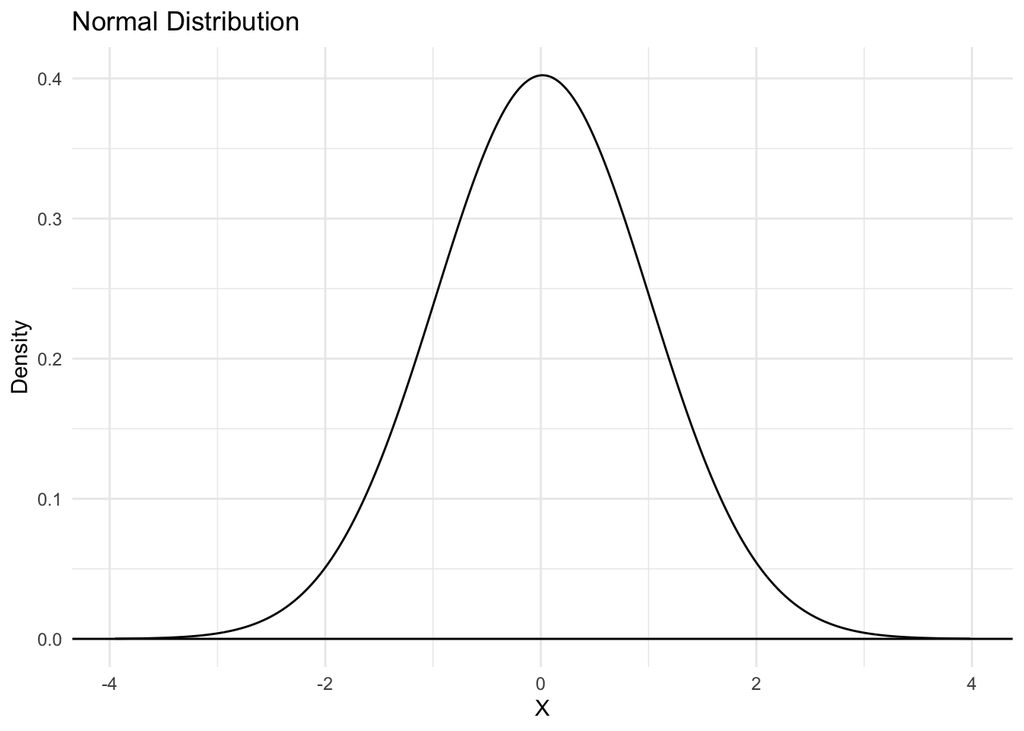

The normal distribution is typically described in terms of two parameters: The population mean $\mu$ and the population standard deviation $\sigma$. If a random variable $X$ is normally distributed, we typically use the notation in Equation 17.1.

$$X \sim N(\mu, \sigma^2).
\tag{17.1}$$

These two parameters affect the shape of the **probability density function (PDF)** $f(x)$, which is formally defined as

$$f(x) = \frac{1}{\sqrt{2 \pi \sigma^2}} e^{-\frac{(x - \mu)^2}{2 \sigma^2}}.
\tag{17.2}$$

In practice, this function returns a bell curve:

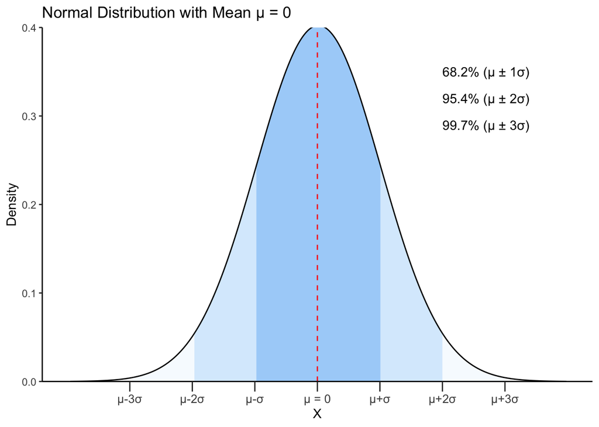

**Quick facts about the Gaussian bell curve**

Quite interestingly,

- 68% all values fall within one standard deviation of the mean,
- 95% within two, and
- 99.7% within three.

In the plot, the $y$-axis indicates the density of population values; note that since the Gaussian distribution is a continuous distribution with technically infinite $x$-values, the probability of any given value must be 0. We can only obtain probabilities for **intervals** of values, which are given by

$$P(a \leq X \leq b) = \int_a^b f(x)dx.
\tag{17.3}$$

We can find the population mean of $X$ with a PDF $f(x)$ via

$$E(X) = \mu = \int_x xf(x)dx,
\tag{17.4}$$

where $E(X)$ denotes the expected value of $X$, i.e., the mean. Essentially, multiplying every value $x$ by its respective probability density $f(x)$ and integrating over all possible values of $x$ will return $E(X) = \mu$.

## 17.3 Discrete distributions

### 17.3.1 Bernoulli distribution

The **Bernoulli distribution** is a discrete probability distribution for random variables which have only two possible outcomes: “positive” (often coded as 1) and “negative” (often coded as 0). Examples of such variables include coin tosses (heads/tails), binary response questions (yes/no), and defect status (defective/non-defective).

If a random variable $X$ follows a Bernoulli distribution, it is determined by the parameter $p$, which is the probability of the positive case:

$$X \sim Bernoulli(p).$$
The **probability mass function (PMF)** of the Bernoulli distribution is given by:
$$P(X = x) =
\begin{cases}
p & \text{if } x = 1 \\
1 - p & \text{if } x = 0
\end{cases}$$

where $0 \leq p \leq 1$. This function shows the probability of $X$ taking on the value of 1 or 0 (cf. Heumann, Schomaker, and Shalabh 2022: 162-163).

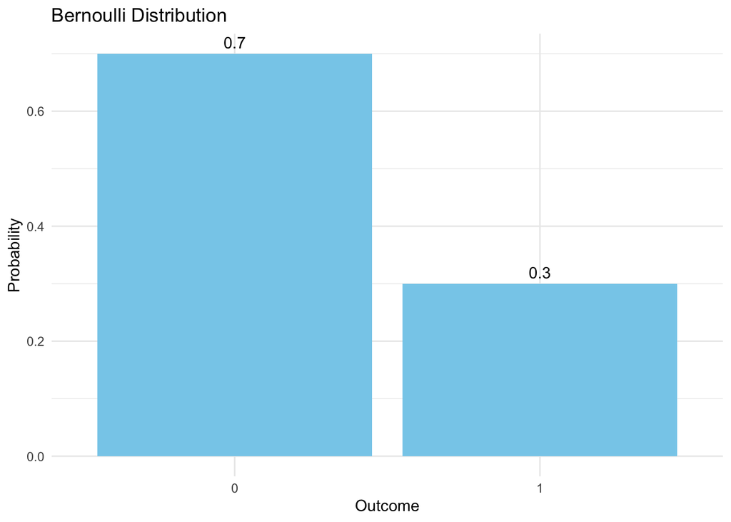

### 17.3.2 Binomial Distribution

The **binomial distribution** is a fairly straightforward extension of the Bernoulli distribution in that it models the number of successes in $n$ independent Bernoulli trials, each with probability $p$ of success. If a random variable $X$ follows a binomial distribution with parameters $n$ and $p$, we write:

$$X \sim Binomial(n,p)
\tag{17.5}$$

The **probability mass function (PMF)** for the binomial distribution is:

$$P(X = k) = \binom{n}{k} p^k (1-p)^{n-k}
\tag{17.6}$$

where:

- $n$ is the number of trials
- $k$ is the number of successes $(0 \leq k \leq n)$
- $p$ is the probability of success on each trial $(0 \leq p \leq 1)$
- $\binom{n}{k}$ is the binomial coefficient (“n choose k”)

Agresti, Alan, and Maria Kateri. 2022. *Foundations of Statistics for Data Scientists: With r and Python*. Boca Raton: CRC Press.

Baguley, Thomas. 2012. *Serious Stats: A Guide to Advanced Statistics for the Behavioral Sciences*. Houndmills, Basingstoke: Palgrave Macmillan.

Heumann, Christian, Michael Schomaker, and Shalabh. 2022. *Introduction to Statistics and Data Analysis: With Exercises, Solutions and Applications in r*. 2nd ed. Cham: Springer. https://doi.org/10.1007/978-3-031-11833-3.